# Week 7: Markov chain Monte Carlo

Tristan Muno

October 21, 2026

## Week 7 goals

By the end of today, you will be able to:

1. Articulate why grid approximation is intractable for realistic models.
2. Explain the **Monte Carlo idea**: approximating integrals by random sampling and counting.
3. Define a **Markov chain** and explain what a *stationary distribution* is.
4. State the **Metropolis acceptance rule** and show why the normalising constant cancels.
5. Explain qualitatively how **Hamiltonian Monte Carlo** differs from random-walk Metropolis, and why it is more efficient.
6. Assess whether a `brms` model has converged, using trace plots, R-hat and effective sample size.
7. Understand that convergence cannot be proven, only falsified, and recognise what non-convergence looks like.

## Today

1. **Where we left off:** why we cannot compute the posterior everywhere
2. **Monte Carlo:** learning from random samples
3. **Markov chains:** the island king and the Metropolis rule
4. **The posterior as a landscape:** Hamiltonian Monte Carlo
5. **Chains, warm-up and convergence:** how we know something went wrong
6. **Back to week 1:** did that model converge?

## Where today fits

Today is the machinery behind **step 5** and the checks of **step 6a**.

Every `brm()` call from week 8 onwards runs what we build today.

Table 1: The 8-step Bayesian workflow. Every homework exercises the steps introduced so far, cumulatively, and the exam runs all eight end to end.

| # | Step | What you produce |
| --- | --- | --- |
| 1 | **Estimand** | The quantity you want to learn about, stated precisely as a target before any model is fitted. |
| 2 | **Data summary** | The data described: measurement, coverage, obvious issues. |
| 3 | **Formal model** | Likelihood and priors written down, the generative model. |
| 4 | **Prior predictive check** | Simulate from the priors, confirm they imply plausible data. |
| 5 | **Fit** | Estimate with `brms`, weakly-informative priors by default. |
| 6a | **MCMC diagnostics** | R-hat, ESS, divergences, trace plots. Did sampling work? |
| 6b | **Posterior predictive check** | Does the fitted model reproduce key features of the data? |
| 7 | **Interpretation** | Answer the estimand on the outcome scale, with uncertainty. |
| 8 | **Limitations** | What the analysis can and cannot support, threats and next steps. |

# Where we left off

## Statistics is (still) counting

Last week’s core claim:

**Note**

**Statistics, at its heart, is counting.** We count what happened, what did not happen, and what could have happened. How much we have counted tells us how much uncertainty remains.

And the key conceptual move of Bayesian inference:

> Probability is a **degree of belief**. Parameters are uncertain, so they get probability distributions. The data are observed, so they are fixed.

## Bayes’ theorem, proportional form

$$\underbrace{P(\theta \mid \text{data})}_{\text{Posterior}}
= \frac{\underbrace{P(\text{data} \mid \theta)}_{\text{Likelihood}} \cdot \underbrace{P(\theta)}_{\text{Prior}}}{\underbrace{P(\text{data})}_{\text{Normalising constant}}}
\propto P(\text{data} \mid \theta) \cdot P(\theta)
\tag{1}$$

The proportional form fixes the posterior’s **shape**. The normalising constant only rescales it so that it integrates to one.

**Important**

**The normalising constant is an integral over the whole parameter space.**

$$P(\text{data}) = \int_{\Theta} P(\text{data} \mid \theta) \cdot P(\theta) \, d\theta
\tag{2}$$

With seven conjectures we added it up on a grid, and for realistic models that is impossible.

## The dimensional explosion

Table 2: Grid approximation evaluates the posterior at every cell, so its cost grows exponentially with the number of parameters. The observable universe holds about 10^80 atoms.

| Parameters | Grid points per parameter | Total grid cells | Feasible? |
| --- | --- | --- | --- |
| 1 | 1,000 | $10^3$ | ✓ |
| 3 | 1,000 | $10^9$ | Barely |
| 10 | 1,000 | $10^{30}$ | No |
| 50 | 1,000 | $10^{150}$ | Never |

A bivariate regression already has three continuous parameters ($\alpha$, $\beta$, $\sigma$). A multilevel model easily has 50.

**Tip**

**We do not need to visit every point of the parameter space.** We need to spend our time where the posterior mass actually is.

# MCMC: name and origins

## Unpacking the acronym

**MCMC = Markov chain Monte Carlo**, two ideas combined.

**Monte Carlo**

Using *random sampling* to approximate quantities that are hard to compute exactly.

The engine: approximate integrals by counting random draws.

**Markov chain**

A sequence of states where the *next state depends only on the current one*.

The mechanism: a random walk whose long-run behaviour is the distribution we want.

**Note**

**MCMC designs a Markov chain whose wandering produces samples from the posterior.** It never requires computing $P(\text{data})$. We teach Monte Carlo first and Markov chains second, the reverse of the acronym.

## Origins I: Los Alamos, 1946

**Stanisław Ulam**, recovering from illness, plays solitaire and wonders: *what is the probability of a successful deal?*

Calculating it exactly is intractable, but simulating many games and counting is natural.

The insight: **random simulation can replace analytical integration**.

Ulam shares the idea with **John von Neumann** and **Nicholas Metropolis** at Los Alamos, where it is applied to neutron diffusion in weapons design.

Metropolis coins the code name *Monte Carlo*, after the [casino in Monaco](https://en.wikipedia.org/wiki/Monte_Carlo_Casino) (Metropolis and Ulam 1949).

**Note**

**The physical problem: how do neutrons travel through fissile material?** Collisions are random, so tracking particles analytically is impossible. Simulating millions of random paths and averaging is feasible. The same logic will, decades later, power Bayesian inference in the social sciences.

## Origins II: from physics to statistics

**1953: the Metropolis algorithm**

Metropolis, Rosenbluth, Rosenbluth, Teller and Teller publish the first MCMC algorithm, written by physicists for physics (Metropolis et al. 1953). The key innovation is the **acceptance rule**: accept a move with a probability that depends on the relative density. We will meet it today.

**Three decades of dormancy**

Statisticians barely knew the method.

**1990: the Bayesian revolution**

Gelfand and Smith (1990) bring Gibbs sampling to statisticians and show that MCMC computes posteriors for realistic models. For a full treatment, see Gelman et al. (2013a) and Gelman et al. (2013b).

**2012 to today: Stan and `brms`**

Stan implements **Hamiltonian Monte Carlo** with NUTS, a far more efficient algorithm (Carpenter et al. 2017). `brms` gives it a formula interface (Bürkner 2017). This is what we use.

# Monte Carlo: random sampling as integration

## The core idea

**Monte Carlo integration** replaces an intractable integral with an average over random samples.

If $\theta^{(1)}, \ldots, \theta^{(S)}$ are independent draws from $p(\theta)$, the law of large numbers gives

$$\mathbb{E}_{p}[f(\theta)] = \int f(\theta)\, p(\theta)\, d\theta \approx \frac{1}{S} \sum_{s=1}^{S} f\!\left(\theta^{(s)}\right)
\tag{3}$$

**How to read the Monte Carlo estimator**

**Note**

**Equation 3 in words.** The average value of some quantity $f(\theta)$ over the whole distribution $p(\theta)$, an integral, is approximately the plain average of that quantity over $S$ random draws from $p(\theta)$. The more draws, the better the approximation, and the error shrinks with $1/\sqrt{S}$.

**Note**

**Samples let us learn a distribution we cannot write down.** With enough draws from the posterior, a histogram of them approximates its shape. And from that shape every summary follows by averaging: means, spreads, credible intervals.

## The $\pi$ example: setup

A quarter circle of radius 1 sits inside the unit square.

$$\text{Area of the quarter circle} = \frac{\pi}{4}, \qquad \text{Area of the square} = 1
\tag{4}$$

1. Draw points $(x, y)$ uniformly at random in the square.
2. A point is *inside* if $x^2 + y^2 \leq 1$.
3. The share of points inside approaches $\pi / 4$:

$$\hat{\pi} = 4 \cdot \frac{\text{points inside}}{S}
\tag{5}$$

**View source**

```r
ggplot() +
  geom_polygon(
    data = bind_rows(tibble(x = 0, y = 0), quarter_circle),
    aes(x = x, y = y),
    fill = col_1,
    alpha = 0.2
  ) +
  geom_path(data = quarter_circle, aes(x = x, y = y), colour = "grey20", linewidth = 1) +
  annotate("text", x = 0.4, y = 0.4, label = "Area == pi/4", parse = TRUE, size = 6) +
  annotate("text", x = 0.88, y = 0.94, label = "Square: area 1", size = 4) +
  coord_equal(xlim = c(0, 1), ylim = c(0, 1), expand = FALSE) +
  theme_classic() +
  labs(x = "x", y = "y", title = "The quarter circle in the unit square")
```

[figure not shown]

Figure 1: The unit square with the quarter circle of radius 1 inside it. The shaded area is pi/4 and the whole square has area 1, so the share of the square covered by the quarter circle is pi/4.

## The $\pi$ example: simulation

**View source**

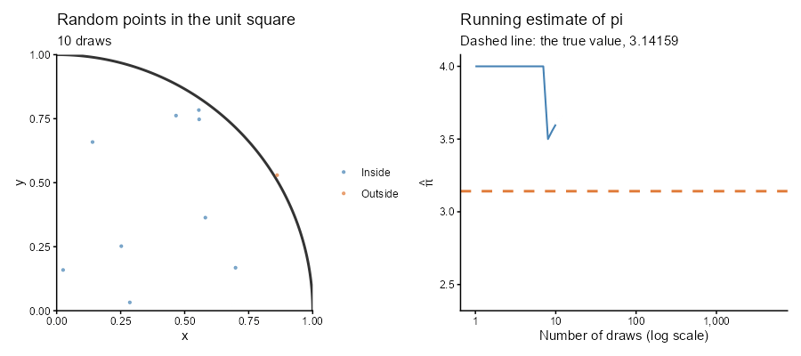

Figure 2: Animation of the pi simulation, from 10 to 5,000 draws. Left: each draw is a point, blue inside the quarter circle and orange outside. Right: four times the share of points inside, which settles toward the true value of pi as the draws accumulate.

```r
# Both pi panels after the first n draws, for the animation and its static twin.
plot_pi <- function(n) {
  shown <- filter(pi_pts, draw <= n)

  p_scatter <- ggplot(shown, aes(x = x, y = y, colour = location)) +
    geom_path(
      data = quarter_circle,
      aes(x = x, y = y),
      inherit.aes = FALSE,
      colour = "grey20",
      linewidth = 1
    ) +
    geom_point(alpha = 0.65, size = 0.8) +
    scale_colour_manual(values = c(Inside = col_1, Outside = col_2), drop = FALSE) +
    coord_equal(xlim = c(0, 1), ylim = c(0, 1), expand = FALSE) +
    theme_classic() +
    labs(
      x = "x",
      y = "y",
      colour = NULL,
      title = "Random points in the unit square",
      subtitle = paste(format(n, big.mark = ","), "draws")
    )

  p_conv <- ggplot(shown, aes(x = draw, y = pi_est)) +
    geom_hline(yintercept = pi, colour = col_2, linetype = "dashed", linewidth = 1) +
    geom_line(colour = col_1, linewidth = 0.7) +
    scale_x_log10(limits = c(1, n_pi), labels = scales::comma) +
    coord_cartesian(ylim = c(2.4, 4)) +
    theme_classic() +
    labs(
      x = "Number of draws (log scale)",
      y = expression(hat(pi)),
      title = "Running estimate of pi",
      subtitle = "Dashed line: the true value, 3.14159"
    )

  p_scatter | p_conv
}

pi_frames <- unique(round(10^seq(1, log10(n_pi), length.out = 70)))
make_gif(plot_pi, pi_frames)
```

## The $\pi$ example: result

**View source**

```r
plot_pi(n_pi)
```

[figure not shown]

Figure 3: The pi simulation after all 5,000 draws. Left: the points, blue inside the quarter circle and orange outside. Right: the running estimate of pi approaches the true value, with an error that shrinks with the square root of the number of draws.

The error shrinks with $1 / \sqrt{S}$, **whatever the number of parameters**. A grid costs $k^d$, exponential in the number of parameters $d$.

## Bridge: from $\pi$ to the posterior

**The $\pi$ problem**

- Scatter points uniformly in the square.
- Count the share inside the quarter circle.
- The share approximates $\pi / 4$.
- We counted, we never integrated.

**The posterior problem**

- We want to *learn* the posterior: its shape, and from that its summaries.
- Samples from it would give us both.
- Scattering points uniformly fails: we do not know where the posterior’s mass is, and most uniform points land where it is practically zero.
- **We need a sampler that finds the mass by itself.**

**Important**

**The gap: how do we sample from a distribution we cannot evaluate everywhere?** A Markov chain spends time in each region in proportion to its posterior probability, without ever computing $P(\text{data})$.

# Markov chains and the Metropolis algorithm

## What is a Markov chain?

A **Markov chain** is a sequence $\theta^{(1)}, \theta^{(2)}, \theta^{(3)}, \ldots$ with the **Markov property**:

$$P\!\left(\theta^{(t+1)} \mid \theta^{(t)},\, \theta^{(t-1)},\, \ldots,\, \theta^{(1)}\right) = P\!\left(\theta^{(t+1)} \mid \theta^{(t)}\right)
\tag{6}$$

**How to read the Markov property**

**Note**

**Equation 6 in words.** The probability of where the chain goes next, given its whole history, is the same as the probability given only where it is now. The chain has no memory beyond its current state.

**Stationary distribution:** after enough steps, the probability of being in any state stops depending on where the chain started. This long-run distribution is the chain’s stationary distribution.

**Tip**

**We can design a Markov chain whose stationary distribution is exactly our posterior.** After enough steps, its states are draws from the posterior, and $P(\text{data})$ was never computed.

## The island king: setup

A king rules a **ring of 10 islands** and wants to visit each in proportion to its population (adapted from McElreath 2020). He can only compare his *current* island with one *proposed neighbour* at a time.

**View source**

```r
p_bar <- islands |>
  ggplot(aes(x = factor(island), y = pop, fill = pop)) +
  geom_col(width = 0.7) +
  geom_text(aes(label = pop), vjust = -0.4, size = 3.5) +
  scale_y_continuous(expand = expansion(mult = c(0, 0.15))) +
  theme_classic() +
  labs(
    x = "Island",
    y = "Population",
    fill = "Population",
    title = "Island populations",
    subtitle = "Goal: time on each island in proportion to its population"
  )

p_ring <- islands |>
  ggplot(aes(x = x, y = y)) +
  annotate(
    "path",
    x = cos(seq(0, 2 * pi, length.out = 200)),
    y = sin(seq(0, 2 * pi, length.out = 200)),
    colour = "grey75",
    linewidth = 0.8
  ) +
  geom_point(aes(fill = pop, size = pop), shape = 21, colour = "grey20") +
  geom_text(aes(x = 1.3 * x, y = 1.3 * y, label = island), size = 3.5) +
  scale_size(range = c(4, 11), guide = "none") +
  coord_equal(xlim = c(-1.4, 1.4), ylim = c(-1.4, 1.4)) +
  theme_void() +
  theme(legend.position = "none") +
  labs(title = "The ring of islands")

(p_bar | p_ring) +
  plot_layout(guides = "collect", widths = c(1.4, 1)) &
  scale_fill_gradient(low = "#DCE6F2", high = "#08306B", limits = c(1, 5))
```

[figure not shown]

Figure 4: The ten islands and their populations, coloured by population in both panels. Left: as a bar chart. Right: as the ring the king travels, where each island has two neighbours and island 10 neighbours island 1. The king never sees the whole list, he only compares neighbours.

## The island king: the rule

At each step the king:

1. proposes a neighbouring island at random (a coin flip: left or right),
2. **always goes** if it is more populated than his current island,
3. otherwise **goes with probability equal to the population ratio**, and stays if not.

$$P(\text{accept}) = \min\!\left(1,\; \frac{\text{pop}_{\text{proposed}}}{\text{pop}_{\text{current}}}\right)
= \min\!\left(1,\; \frac{P(\theta^* \mid \text{data})}{P(\theta^{(t)} \mid \text{data})}\right)
\tag{7}$$

**How to read the acceptance rule**

**Note**

**Equation 7 in words.** The probability of accepting the proposed move is the ratio of the proposed to the current population, but never more than 1. For a parameter, population becomes posterior probability: $\theta^*$ is the proposed value and $\theta^{(t)}$ the current one.

## Why $P(\text{data})$ cancels

Substitute Bayes’ theorem (Equation 1) into the ratio of Equation 7:

$$\frac{P(\theta^* \mid \text{data})}{P(\theta^{(t)} \mid \text{data})}
= \frac{P(\text{data} \mid \theta^*) \cdot P(\theta^*) \,/\, P(\text{data})}{P(\text{data} \mid \theta^{(t)}) \cdot P(\theta^{(t)}) \,/\, P(\text{data})}
= \frac{P(\text{data} \mid \theta^*) \cdot P(\theta^*)}{P(\text{data} \mid \theta^{(t)}) \cdot P(\theta^{(t)})}
\tag{8}$$

**Important**

**$P(\text{data})$ cancels exactly in the ratio.** The acceptance rule only needs likelihood times prior, which we can always compute. The intractable integral of Equation 2 is never evaluated.

## The island king: demonstration

**View source**

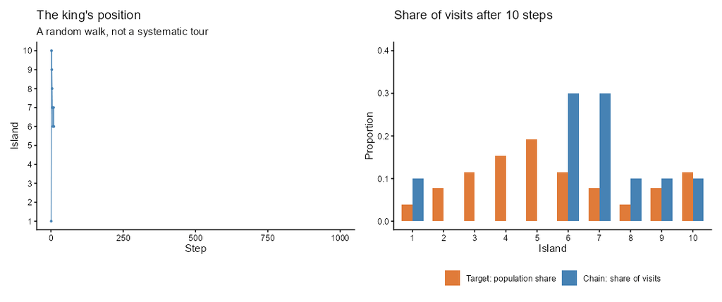

Figure 5: Animation of the king’s first 1,000 steps. Left: his position at every step, a random walk. Right: the share of his visits to each island so far (blue) against each island’s share of the population (orange).

```r
# Trace of the first n_trace steps and the share of visits after n_hist steps.
plot_king <- function(n_trace, n_hist = n_trace, x_max = 1000) {
  p_trace <- king_df |>
    filter(step <= n_trace) |>
    ggplot(aes(x = step, y = island)) +
    geom_line(colour = col_1, linewidth = 0.5, alpha = 0.8) +
    geom_point(colour = col_1, size = 0.7) +
    scale_x_continuous(limits = c(1, x_max)) +
    scale_y_continuous(breaks = 1:n_islands, limits = c(1, n_islands)) +
    theme_classic() +
    labs(
      x = "Step",
      y = "Island",
      title = "The king's position",
      subtitle = "A random walk, not a systematic tour"
    )

  visits <- king_df |>
    filter(step <= n_hist) |>
    count(island) |>
    complete(island = 1:n_islands, fill = list(n = 0)) |>
    mutate(share = n / sum(n))

  p_hist <- islands |>
    left_join(visits, by = "island") |>
    pivot_longer(c(target, share), names_to = "type", values_to = "proportion") |>
    mutate(
      type = factor(
        type,
        levels = c("target", "share"),
        labels = c("Target: population share", "Chain: share of visits")
      )
    ) |>
    ggplot(aes(x = factor(island), y = proportion, fill = type)) +
    geom_col(position = "dodge", width = 0.7) +
    scale_fill_manual(values = c(col_2, col_1)) +
    coord_cartesian(ylim = c(0, 0.4)) +
    theme_classic() +
    theme(legend.position = "bottom") +
    labs(
      x = "Island",
      y = "Proportion",
      fill = NULL,
      title = paste("Share of visits after", format(n_hist, big.mark = ","), "steps")
    )

  p_trace | p_hist
}

make_gif(plot_king, seq(10, 1000, by = 10), width = 10.5, height = 4.4)
```

## The island king: result

**View source**

```r
plot_king(1000, n_steps)
```

[figure not shown]

Figure 6: The island king after the animation. Left: his position during the first 1,000 steps. Right: the share of visits after 10,000 steps (blue) matches each island’s share of the population (orange), although the king only ever compared neighbours.

## From islands to parameters

Table 3: Every element of the island king story and its counterpart in Bayesian inference.

| Island world | Bayesian inference |
| --- | --- |
| Ring of 10 islands | Parameter space, the plausible values of $\theta$ |
| Population of island $k$ | Posterior probability $P(\theta_k \mid \text{data})$ |
| King’s current island | Current parameter value $\theta^{(t)}$ |
| Proposed neighbouring island | Proposed parameter value $\theta^*$ |
| Population ratio | Posterior ratio $P(\theta^* \mid \text{data}) \,/\, P(\theta^{(t)} \mid \text{data})$ |
| Share of time on island $k$ | Posterior probability of $\theta_k$ |
| **Total population (unknown)** | **$P(\text{data})$: never needed, always cancels** |

**Note**

**The Metropolis algorithm builds a Markov chain whose stationary distribution is the posterior.** Its samples approximate the shape of the posterior, and *therefore* any posterior quantity: means, credible intervals, tail probabilities.

## Mapping a landscape on foot

The king’s random walk works, but it is **slow**. Imagine mapping a mountain range blindfolded, one small random step at a time.

**View source**

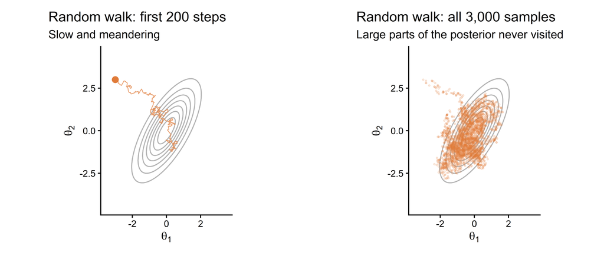

```r
# Samples drawn over the contour lines of the 2D posterior.
plot_samples_2d <- function(df, colour, title, subtitle, path = FALSE, path_alpha = 0.7) {
  p <- ggplot() +
    geom_contour(
      data = land2d,
      aes(x = x, y = y, z = density),
      colour = "grey70",
      bins = 8
    )
  if (path) {
    p <- p +
      geom_path(
        data = df,
        aes(x = x, y = y),
        colour = colour,
        alpha = path_alpha,
        linewidth = 0.4
      ) +
      geom_point(data = df[1, ], aes(x = x, y = y), colour = colour, size = 2.5)
  } else {
    p <- p + geom_point(data = df, aes(x = x, y = y), colour = colour, alpha = 0.15, size = 0.5)
  }
  p +
    coord_equal(xlim = c(-3.5, 3.5), ylim = c(-4.5, 4.5)) +
    theme_classic() +
    labs(x = expression(theta[1]), y = expression(theta[2]), title = title, subtitle = subtitle)
}

p_rw_path <- plot_samples_2d(
  rw_df[1:200, ],
  col_2,
  "Random walk: first 200 steps",
  "Slow and meandering",
  path = TRUE
)
p_rw_all <- plot_samples_2d(
  rw_df,
  col_2,
  "Random walk: all 3,000 samples",
  "Large parts of the posterior never visited"
)

p_rw_path + plot_spacer() + p_rw_all + plot_layout(widths = c(1, 0.05, 1))
```

Many proposals are rejected, successive samples are nearly identical, and 3,000 samples carry little information.

**We can be much more efficient than walking randomly.**

# The posterior as a landscape and HMC

## The posterior as a landscape (1D)

Think of probability as **height**.

**View source**

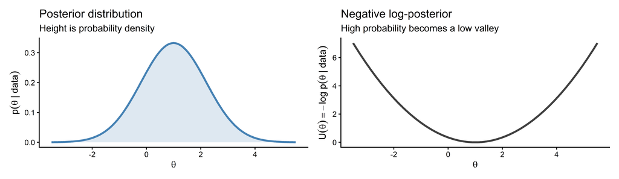

Figure 8: The same posterior in two framings. Left: the density, where height is probability density and the peak is the most plausible value. Right: the negative log-posterior, where that peak becomes the bottom of a valley.

```r
p_density <- land1d |>
  ggplot(aes(x = theta, y = density)) +
  geom_area(fill = col_1, alpha = 0.18) +
  geom_line(colour = col_1, linewidth = 1.1) +
  theme_classic() +
  labs(
    x = expression(theta),
    y = expression(p(theta ~ "|" ~ data)),
    title = "Posterior distribution",
    subtitle = "Height is probability density"
  )

p_neglog <- land1d |>
  ggplot(aes(x = theta, y = U)) +
  geom_line(colour = "grey25", linewidth = 1.1) +
  theme_classic() +
  labs(
    x = expression(theta),
    y = expression(U(theta) == -log ~ p(theta ~ "|" ~ data)),
    title = "Negative log-posterior",
    subtitle = "High probability becomes a low valley"
  )

p_density | p_neglog
```

**Note**

**The negative log is used mainly for computational reasons.** Conceptually it only flips the problem: instead of hills and peaks, we look for valleys and lows. The reasons are in the appendix.

## The posterior as a landscape (2D)

**View source**

```r
# Project a surface given as quadrilateral cells (cell, corner, x, y, z) into 2D,
# and sort the cells from far to near so nearer ones are painted on top.
project_surface <- function(cells, azimuth = 35, elevation = 30) {
  az <- azimuth * pi / 180
  el <- elevation * pi / 180
  cells |>
    mutate(
      sx = x * cos(az) - y * sin(az),
      depth = x * sin(az) + y * cos(az),
      sy = z * cos(el) + depth * sin(el),
      dist = depth * cos(el) - z * sin(el)
    ) |>
    group_by(cell) |>
    mutate(height = mean(z), cell_dist = mean(dist)) |>
    ungroup() |>
    arrange(desc(cell_dist), cell, corner) |>
    mutate(cell = fct_inorder(as.character(cell)))
}

# Quadrilateral cells of a (u, v) grid, mapped to (x, y) by to_xy.
grid_cells <- function(u, v, to_xy, z_fun) {
  expand_grid(i = seq_along(u)[-1], j = seq_along(v)[-1]) |>
    mutate(cell = row_number()) |>
    cross_join(tibble(corner = 1:4, di = c(-1, 0, 0, -1), dj = c(-1, -1, 0, 0))) |>
    mutate(to_xy(u[i + di], v[j + dj])) |>
    mutate(z = z_fun(x, y))
}

# The bell on a rectangle, the bowl on ellipses that follow its contours.
chol_2d <- t(chol(Sigma_2d))
bell <- grid_cells(
  seq(-3.5, 3.5, length.out = 45),
  seq(-4.5, 4.5, length.out = 45),
  function(u, v) tibble(x = u, y = v),
  function(x, y) 4 * exp(-neg_log_2d(x, y))
) |>
  project_surface()
bowl <- grid_cells(
  seq(0, 2.8, length.out = 16),
  seq(0, 2 * pi, length.out = 49),
  function(u, v) {
    tibble(
      x = chol_2d[1, 1] * u * cos(v),
      y = chol_2d[2, 1] * u * cos(v) + chol_2d[2, 2] * u * sin(v)
    )
  },
  function(x, y) 0.55 * neg_log_2d(x, y)
) |>
  project_surface()

plot_contour <- function(z_var, title, subtitle) {
  land2d |>
    ggplot(aes(x = x, y = y, z = .data[[z_var]])) +
    geom_contour_filled(bins = 11) +
    coord_equal(expand = FALSE) +
    theme_classic() +
    theme(legend.position = "none") +
    labs(x = expression(theta[1]), y = expression(theta[2]), title = title, subtitle = subtitle)
}

plot_surface <- function(surface, title) {
  ggplot(surface, aes(x = sx, y = sy, group = cell, fill = height)) +
    geom_polygon(colour = "grey25", linewidth = 0.08) +
    scale_fill_viridis_c() +
    coord_equal() +
    theme_void() +
    theme(legend.position = "none") +
    labs(title = title)
}

(plot_contour("density", "Posterior, from above", "Yellow is high probability") |
  plot_contour("neg_log", "Negative log-posterior, from above", "Dark is high probability")) /
  (plot_surface(bell, "Posterior in 3D: a bell") |
    plot_surface(bowl, "Negative log-posterior in 3D: a bowl"))
```

[figure not shown]

Figure 9: A posterior for two correlated parameters, seen from above (top) and in 3D (bottom). Left: the posterior density, a bell whose peak is the most plausible pair of values (yellow is high). Right: the negative log-posterior, a bowl whose lowest point is that same pair (dark is low).

## HMC: the ball on the landscape

**Hamiltonian Monte Carlo** (HMC) simulates *Hamiltonian dynamics*, the physics of a frictionless ball rolling on the negative log-posterior (Hoffman and Gelman 2014; Gelman et al. 2013b).

- **Random walk:** the chain takes a sequence of small, blind random steps.
- **HMC:** the chain gets *momentum*, like a ball we kick across the curved surface. Each step is one kick in a random direction and strength, after which the ball rolls for a fixed simulated time. Where it stops is the proposed next sample.

The parameter value is the ball’s position, the negative log-posterior its **potential energy**, and the kick gives it **kinetic energy**. The total stays constant, so the ball speeds up through the valley and slows down on the slopes.

**Note**

**The next slides show three consecutive trajectories of one chain.** Each trajectory starts where the previous one stopped, with a fresh kick.

## HMC: trajectory 1

**View source**

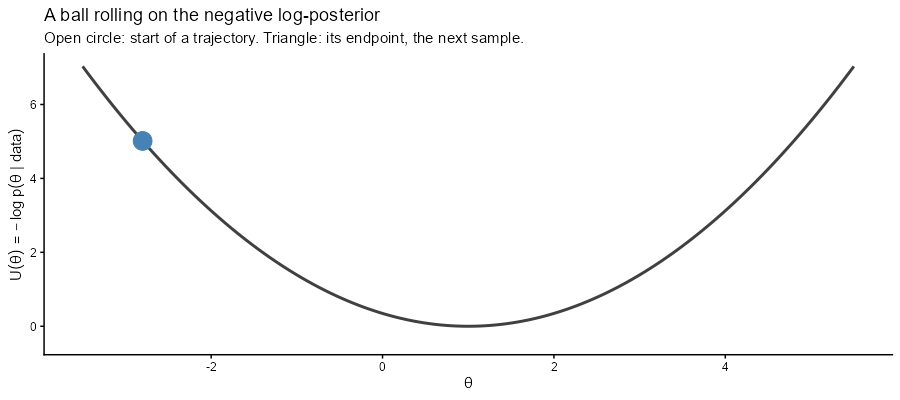

Figure 10: Animation of the first HMC trajectory. The ball starts on the left shoulder of the negative log-posterior, is kicked to the right, rolls through the valley and stops on the right side. Its endpoint is the next sample.

```r
# The ball on the landscape at time t_now. Trajectories before `fade_before` are grey.
plot_hmc_frame <- function(t_now, fade_before = 1, show = 1:3) {
  shown <- filter(hmc_traj, t <= t_now, traj %in% show)
  active <- filter(shown, as.integer(traj) >= fade_before)
  faded <- filter(shown, as.integer(traj) < fade_before)
  # The ball rolls until the endpoint, where the triangle takes over.
  ball <- slice_tail(shown, n = 1) |> filter(step < 28)
  ends <- shown |> group_by(traj) |> filter(step == 28) |> ungroup()

  ggplot() +
    geom_line(data = land1d, aes(x = theta, y = U), colour = "grey25", linewidth = 1) +
    geom_path(
      data = faded,
      aes(x = theta, y = potential, group = traj),
      colour = "grey70",
      linewidth = 1
    ) +
    geom_path(data = active, aes(x = theta, y = potential, colour = traj), linewidth = 1) +
    geom_point(
      data = filter(active, step == 0),
      aes(x = theta, y = potential, colour = traj),
      shape = 21,
      fill = "white",
      size = 4,
      stroke = 1.5
    ) +
    geom_point(data = ends, aes(x = theta, y = potential, colour = traj), shape = 17, size = 4) +
    geom_rug(
      data = ends,
      aes(x = theta, colour = traj),
      sides = "b",
      linewidth = 1.5,
      length = unit(0.05, "npc")
    ) +
    geom_point(data = ball, aes(x = theta, y = potential, colour = traj), size = 6) +
    scale_colour_manual(values = traj_cols, limits = names(traj_cols)) +
    coord_cartesian(xlim = c(-3.5, 5.5), ylim = c(-0.4, 7)) +
    theme_classic() +
    theme(legend.position = "none") +
    labs(
      x = expression(theta),
      y = expression(U(theta) == -log ~ p(theta ~ "|" ~ data)),
      title = "A ball rolling on the negative log-posterior",
      subtitle = "Open circle: start of a trajectory. Triangle: its endpoint, the next sample."
    )
}

# The same trajectories as positions over simulated time, like a trace plot.
plot_hmc_time <- function(t_now) {
  shown <- filter(hmc_traj, t <= t_now)
  ends <- filter(shown, step == 28)
  ggplot(shown, aes(x = t, y = theta, colour = traj)) +
    geom_hline(yintercept = mu_tgt, colour = "grey70", linetype = "dashed") +
    geom_path(linewidth = 1) +
    geom_point(data = ends, shape = 17, size = 4) +
    scale_colour_manual(values = traj_cols, limits = names(traj_cols)) +
    coord_cartesian(xlim = c(1, nrow(hmc_traj)), ylim = c(-3.5, 5.5)) +
    theme_classic() +
    theme(legend.position = "none") +
    labs(
      x = "Leapfrog step, over all three trajectories",
      y = expression(theta),
      title = "Position over simulated time",
      subtitle = "Dashed line: the posterior mode"
    )
}

make_gif(plot_hmc_frame, seq_len(traj_end(1)), fps = 10)
```

## HMC: trajectory 2

**View source**

```r
make_gif(
  function(t_now) plot_hmc_frame(t_now, fade_before = 2),
  (traj_end(1) + 1):traj_end(2),
  fps = 10
)
```

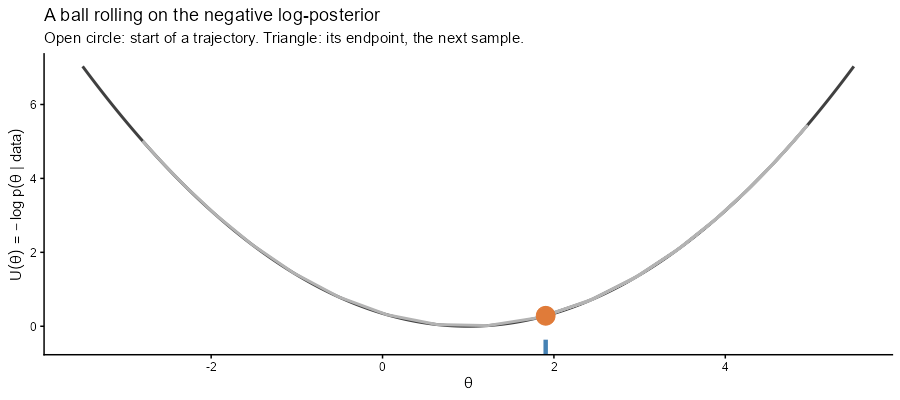

Figure 11: Animation of the second HMC trajectory, starting where the first one (grey) stopped. A kick to the right sends the ball up the right shoulder, the slope turns it back, and it ends on the left side of the valley.

## HMC: trajectory 3

**View source**

```r
make_gif(
  function(t_now) plot_hmc_frame(t_now, fade_before = 3),
  (traj_end(2) + 1):traj_end(3),
  fps = 10
)
```

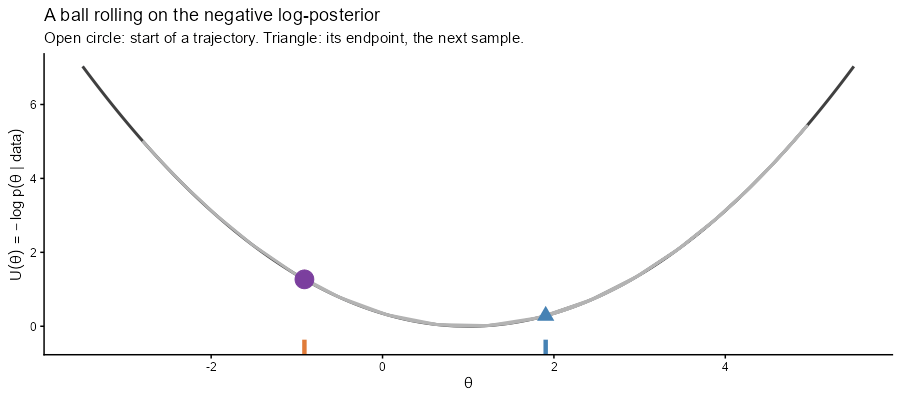

Figure 12: Animation of the third HMC trajectory, starting where the second one stopped. A kick to the left sends the ball up the left shoulder, back across the valley and high onto the right shoulder, a less plausible but still possible sample.

## HMC: one chain, three trajectories

**View source**

```r
make_gif(
  function(t_now) plot_hmc_frame(t_now) / plot_hmc_time(t_now),
  seq(1, nrow(hmc_traj), by = 2),
  height = 5.5,
  fps = 10
)
```

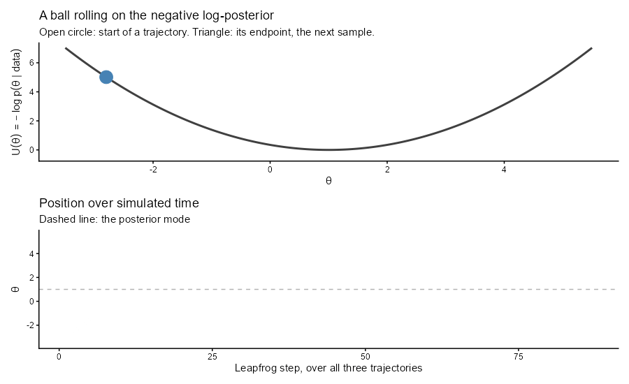

Figure 13: Animation of all three trajectories in sequence, one colour each. Top: the ball on the negative log-posterior. Bottom: its position over simulated time. Each triangle is an accepted sample, and consecutive samples land far apart.

## HMC: the three trajectories

**View source**

```r
map(1:3, function(k) {
  plot_hmc_frame(traj_end(k), show = k) +
    labs(
      y = expression(U(theta)),
      title = paste("Trajectory", k),
      subtitle = paste0(
        "From ",
        round(first(hmc_traj$theta[hmc_traj$traj == k]), 1),
        " to ",
        round(last(hmc_traj$theta[hmc_traj$traj == k]), 1)
      )
    )
}) |>
  wrap_plots(nrow = 1)
```

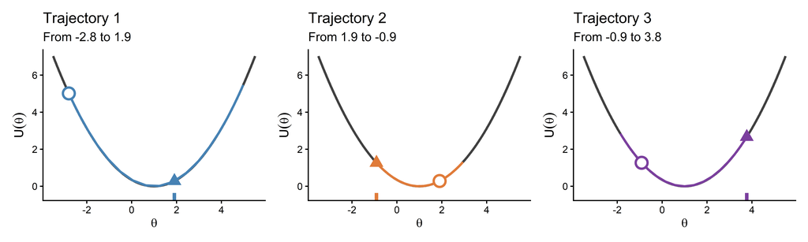

Figure 14: The three consecutive HMC trajectories of the animations, one per panel. Each starts at the open circle, where the previous one ended, and its endpoint (triangle) is the next sample. All three were accepted, because the simulated physics conserves energy almost exactly.

The kicks are random, the rolling is physics. Even a kick into an unlikely region explores the landscape on the way.

## HMC against the random walk

**View source**

```r
p_rw_ref <- p_rw_all + labs(title = "Random walk", subtitle = "3,000 samples, for reference")
p_hmc_path <- plot_samples_2d(
  hmc_df[1:200, ],
  col_1,
  "HMC: 200 steps",
  "Long jumps across the posterior",
  path = TRUE,
  path_alpha = 0.45
)
p_hmc_all <- plot_samples_2d(hmc_df, col_1, "HMC: 3,000 samples", "Even coverage")

p_rw_ref +
  plot_spacer() +
  p_hmc_path +
  plot_spacer() +
  p_hmc_all +
  plot_layout(widths = c(1, 0.08, 1, 0.08, 1))
```

[figure not shown]

Figure 15: The same posterior, the same 3,000 iterations and the same starting point for both samplers. Left: random-walk Metropolis, for reference. Middle: the first 200 HMC steps already cross the whole posterior. Right: all 3,000 HMC samples cover it evenly.

## What Stan adds

What you saw is a **conceptual** introduction to HMC.

The full algorithm has more moving parts:

- the **step size** of the simulated physics, how far the ball moves per update,
- the **number of steps**, how long the ball rolls (NUTS chooses this anew for every trajectory),
- the **mass matrix**, which rescales the landscape so that correlated parameters are as easy as uncorrelated ones,
- the **accept step**, which corrects for the small errors of the simulation,
- **divergence detection**, which flags trajectories where the simulation broke down.

**Tip**

**Stan tunes all of these automatically.** The formal version is in the appendix.

# Multiple chains, warm-up and convergence

## Why one chain is not enough

A single chain has three problems:

**1. Starting-point sensitivity.** Every chain starts somewhere, and early samples reflect the start rather than the posterior. One chain alone cannot tell us when it has arrived.

**2. Invisible trapping.** A chain may explore only part of the posterior, for example one of two peaks. With one chain, this failure is invisible.

**3. No benchmark.** Convergence can only be judged by comparing *several* chains started at *different* points. If they agree, that is evidence of convergence. If they disagree, non-convergence is visible.

## Why one chain is not enough: illustrated

**View source**

```r
set.seed(42)

log_bimodal <- function(x) {
  log(0.5 * dnorm(x, -2.5, 0.6) + 0.5 * dnorm(x, 2.5, 0.6))
}

metropolis_bimodal <- function(start, n = 1000, step = 0.3) {
  x <- numeric(n)
  x[1] <- start
  for (t in 2:n) {
    prop <- x[t - 1] + rnorm(1, 0, step)
    log_alpha <- log_bimodal(prop) - log_bimodal(x[t - 1])
    x[t] <- if (log(runif(1)) < log_alpha) prop else x[t - 1]
  }
  x
}

chain_left <- metropolis_bimodal(start = -2.3)
chain_right <- metropolis_bimodal(start = 2.3)

chain_df <- bind_rows(
  tibble(iteration = 1:1000, value = chain_left, chain = "Chain A: starts near the left peak"),
  tibble(iteration = 1:1000, value = chain_right, chain = "Chain B: starts near the right peak")
)

dens_df <- tibble(
  x = seq(-5, 5, length.out = 400),
  y = 0.5 * dnorm(x, -2.5, 0.6) + 0.5 * dnorm(x, 2.5, 0.6)
)

p_trace_local <- chain_df |>
  ggplot(aes(x = iteration, y = value, colour = chain)) +
  geom_line(alpha = 0.8, linewidth = 0.5) +
  scale_colour_manual(values = c(col_2, col_1)) +
  theme_classic() +
  theme(legend.position = "right", legend.title = element_blank()) +
  labs(
    x = "Iteration",
    y = expression(theta),
    title = "Trace plot: each chain is stationary, but trapped"
  )

p_density_local <- ggplot() +
  geom_area(data = dens_df, aes(x = x, y = y), fill = "grey30", alpha = 0.12) +
  geom_line(data = dens_df, aes(x = x, y = y), colour = "grey30", linewidth = 1.1) +
  geom_rug(
    data = tibble(v = chain_left),
    aes(x = v),
    colour = col_2,
    alpha = 0.35,
    sides = "b",
    length = unit(0.07, "npc")
  ) +
  geom_rug(
    data = tibble(v = chain_right),
    aes(x = v),
    colour = col_1,
    alpha = 0.35,
    sides = "t",
    length = unit(0.07, "npc")
  ) +
  theme_classic() +
  labs(
    x = expression(theta),
    y = "Density",
    title = "The true posterior and where each chain sampled"
  )

p_trace_local / p_density_local
```

[figure not shown]

Figure 16: A posterior with two separated peaks. Top: trace plots of two chains, each stationary but stuck near the peak it started at. Bottom: the true posterior with each chain’s samples as ticks, orange below and blue above. Each chain alone looks healthy and tells only half the story.

## Warm-up

**View source**

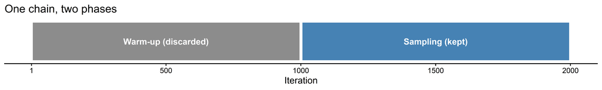

Figure 17: The default brms run per chain: 2,000 iterations, of which the first 1,000 are warm-up and discarded. With four chains, the remaining 4 x 1,000 = 4,000 draws are the posterior samples.

```r
tibble(
  phase = factor(
    c("Warm-up (discarded)", "Sampling (kept)"),
    levels = c("Warm-up (discarded)", "Sampling (kept)")
  ),
  x_start = c(1, 1001),
  x_end = c(1000, 2000),
  x_label = c(500, 1500)
) |>
  ggplot() +
  geom_rect(
    aes(xmin = x_start, xmax = x_end, ymin = 0, ymax = 1, fill = phase),
    colour = "white",
    linewidth = 1.5
  ) +
  geom_text(
    aes(x = x_label, y = 0.5, label = phase),
    colour = "white",
    fontface = "bold",
    size = 3.6
  ) +
  scale_fill_manual(values = c("grey55", col_1)) +
  scale_x_continuous(breaks = c(1, 500, 1000, 1500, 2000)) +
  theme_classic() +
  theme(
    axis.line.y = element_blank(),
    axis.text.y = element_blank(),
    axis.ticks.y = element_blank(),
    legend.position = "none"
  ) +
  labs(x = "Iteration", y = NULL, title = "One chain, two phases")
```

**Warm-up:** the chain travels from its starting point to the region where the posterior mass is. Meanwhile Stan **automatically tunes its physics simulation** to be efficient for this particular posterior (details).

**Sampling:** the tuning is frozen, and every draw is kept. By default `brms` runs **4 chains** of 2,000 iterations each, so 4,000 posterior draws.

## Four chains on the landscape

**View source**

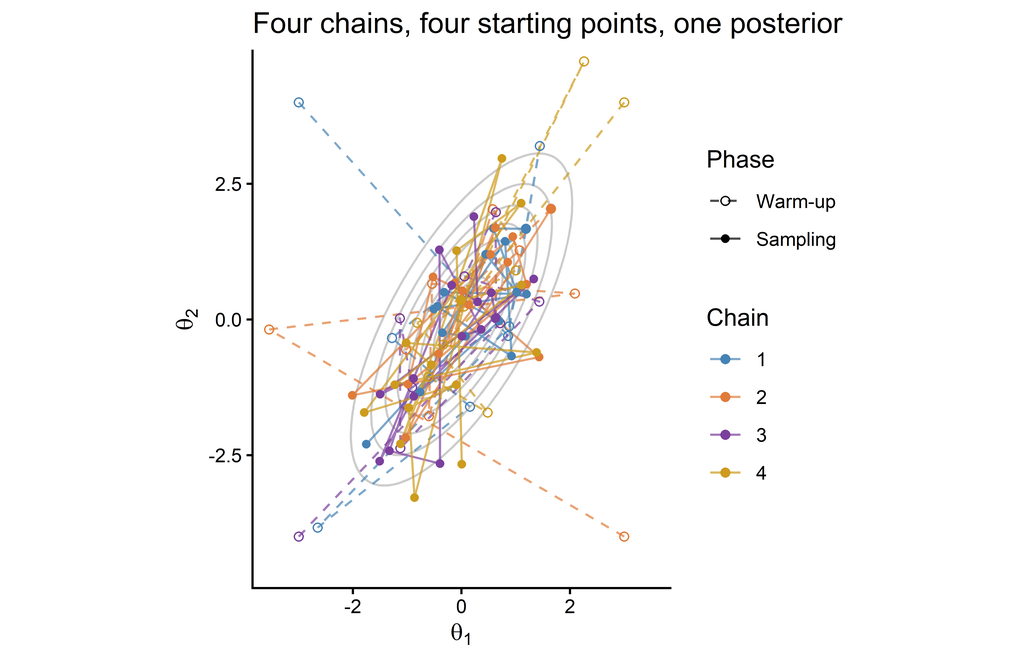

Figure 18: Four HMC chains on the posterior of two correlated parameters, one colour each, started in four different corners. Dashed lines with open circles: the first 8 warm-up iterations, travelling into the posterior. Solid lines with filled points: the next 15 sampling iterations, where all four chains overlap.

```r
chains_warm <- four_chains |>
  filter(iteration <= n_warm + 1) |>
  mutate(phase = "Warm-up")
chains_samp <- four_chains |>
  filter(iteration > n_warm) |>
  mutate(phase = "Sampling")
chains_phases <- bind_rows(chains_warm, chains_samp) |>
  mutate(phase = factor(phase, levels = c("Warm-up", "Sampling")))

ggplot(chains_phases, aes(x = x, y = y, colour = chain)) +
  geom_contour(
    data = land2d,
    aes(x = x, y = y, z = density),
    inherit.aes = FALSE,
    colour = "grey80",
    bins = 8
  ) +
  geom_path(
    aes(linetype = phase, group = interaction(chain, phase)),
    linewidth = 0.5,
    alpha = 0.7
  ) +
  geom_point(aes(shape = phase), size = 1.6) +
  scale_colour_manual(values = chain_cols) +
  scale_linetype_manual(values = c(`Warm-up` = "dashed", Sampling = "solid")) +
  scale_shape_manual(values = c(`Warm-up` = 1, Sampling = 16)) +
  coord_equal(xlim = c(-3.5, 3.5), ylim = c(-4.5, 4.5)) +
  theme_classic() +
  labs(
    x = expression(theta[1]),
    y = expression(theta[2]),
    colour = "Chain",
    linetype = "Phase",
    shape = "Phase",
    title = "Four chains, four starting points, one posterior"
  )
```

## Convergence: what we can and cannot know

**Important**

**Convergence cannot be proven, it can only be falsified.** A chain that looks converged might not be: it may have missed a distant peak. No finite set of statistics certifies convergence.

This mirrors Karl Popper’s falsificationism: we cannot confirm that a chain has converged, we can only fail to detect that it has not.

> Diagnostics are **tests for non-convergence**, not certificates of convergence.

So run them every time, report them, and treat them as minimum requirements. Several chains and longer runs are further safeguards.

## Convergence diagnostics

Four diagnostics, all **reported by `brms`**:

**Trace plot:** sampled values over iterations, one line per chain. Converged chains look like a stationary, noisy band, the “hairy caterpillar”, and overlap.

**$\hat{R}$ (R-hat):** compares the variance between chains with the variance within them (Vehtari et al. 2021).

$$\hat{R} = \sqrt{\frac{\widehat{\text{Var}}^+(\theta \mid y)}{W}}
\tag{9}$$

If all chains sample the same distribution, $\hat{R} \approx 1$. **Rule of thumb:** $\hat{R} < 1.01$.

**Effective sample size (ESS):** successive draws are correlated, so they carry less information than independent ones. ESS estimates the equivalent number of independent draws, as Bulk-ESS (centre) and Tail-ESS (tails). **Rule of thumb:** ESS above 400.

**Divergent transitions:** HMC trajectories where the physics simulation broke down. Even a handful signals a problem with the model or the posterior’s geometry.

**How to read R-hat**

**Note**

**Equation 9 in words.** The numerator is an estimate of the posterior variance that pools all chains, so it grows if the chains disagree, and $W$ is the average variance within each chain. If the chains agree, both are about equal and the ratio is about 1.

## What convergence looks like

**View source**

```r
plot_traces <- function(chains, title) {
  chains |>
    ggplot(aes(x = iteration, y = value, colour = chain)) +
    geom_line(alpha = 0.75, linewidth = 0.45) +
    scale_colour_manual(values = chain_cols) +
    theme_classic() +
    theme(legend.position = "none") +
    labs(x = "Iteration", y = expression(theta), title = title)
}

plot_traces(good_chains, "Converged: stationary and overlapping") /
  plot_traces(bad_chains, "Not converged: separated and trending")
```

[figure not shown]

Figure 19: Trace plots of four chains on the same Normal(0, 1) target. Top: well-mixed chains, stationary and overlapping, the hairy caterpillar. Bottom: chains with extreme starting points and a tiny step size stay separated, a clear diagnostic failure.

# The three moves of MCMC

## Synthesis

**1. Monte Carlo:** learn a distribution from random samples, and approximate any quantity by averaging over them. The error shrinks with $1 / \sqrt{S}$, whatever the number of parameters.

**2. Markov chain:** a sequence of states, each depending only on the previous one, built so that its **stationary distribution** is the posterior.

**3. Metropolis and HMC:** an acceptance rule that uses only the **ratio** of posterior values, so $P(\text{data})$ **cancels** and is never computed. HMC makes the random exploration far more efficient by treating the posterior as a landscape and simulating a ball rolling across it, instead of taking blind steps.

**Note**

**In practice, Stan and `brms` take care of all of this.** You specify a likelihood and priors, and `brms` runs 4 chains of HMC on the resulting landscape. It is still good to know what happens behind the scenes, because that is what the diagnostics are about.

# Back to week 1: did it converge?

## The week 1 model

In week 1 we fitted a model of confidence on semester. Read only the **last three columns** of its summary: `Rhat`, `Bulk_ESS` and `Tail_ESS`.

```
 Family: gaussian
  Links: mu = identity
Formula: conf_stats ~ 0 + Intercept + semester
   Data: model_df (Number of observations: 6)
  Draws: 4 chains, each with iter = 2000; warmup = 1000; thin = 1;
         total post-warmup draws = 4000

Regression Coefficients:
          Estimate Est.Error l-95% CI u-95% CI Rhat Bulk_ESS Tail_ESS
Intercept     3.29      1.74     0.15     6.96 1.01     1108     1375
semester      0.47      0.33    -0.23     1.07 1.00     1108     1194

Further Distributional Parameters:
      Estimate Est.Error l-95% CI u-95% CI Rhat Bulk_ESS Tail_ESS
sigma     1.56      0.52     0.84     2.86 1.00     1203     1389

Draws were sampled using sampling(NUTS). For each parameter, Bulk_ESS
and Tail_ESS are effective sample size measures, and Rhat is the potential
scale reduction factor on split chains (at convergence, Rhat = 1).
```

## The week 1 trace plots

**View source**

```r
mcmc_plot(fit_week01, type = "trace") +
  scale_colour_manual(values = chain_cols) +
  theme_classic()
```

[figure not shown]

Figure 20: Trace plots for the three parameters of the week 1 model, four chains each. The chains are stationary and overlap completely, the hairy caterpillar, so the plots show no sign of non-convergence.

Largest R-hat 1.005, smallest ESS 1108, 0 divergent transitions, overlapping chains. **No evidence of non-convergence**, and that is the strongest statement the diagnostics allow.

## Next time

There is **no session next week**.

In week 8 we fit our **first `brms` model together**, a bivariate linear regression, and run it through the whole workflow.

Everything from today runs underneath it.

# Wrap-up

## Learning goals: achieved?

Table 4: The week 7 learning goals, each with its key answer and the part of the session that covers it.

| # | Learning goal | Key answer | Where |
| --- | --- | --- | --- |
| 1 | Why is grid approximation intractable? | Its cost grows exponentially with the number of parameters, 50 parameters means $10^{150}$ cells | Where we left off |
| 2 | What is the Monte Carlo idea? | Learn a distribution from random samples and average over them, with an error that shrinks with $1/\sqrt{S}$ in any dimension | Monte Carlo |
| 3 | What is a Markov chain and its stationary distribution? | A memoryless sequence of states, whose long-run distribution no longer depends on the start | Markov chains |
| 4 | Why does $P(\text{data})$ cancel? | The acceptance rule uses a posterior *ratio*, and $P(\text{data})$ sits above and below the line | Why it cancels |
| 5 | How does HMC differ from Metropolis? | It simulates a ball kicked across the posterior landscape instead of taking blind random steps, so samples land far apart | The landscape |
| 6 | How do I assess whether a `brms` model converged? | $\hat{R} < 1.01$, ESS above 400, no divergences, overlapping trace plots | Back to week 1 |
| 7 | Why can convergence not be proven? | Diagnostics test for non-convergence, they never certify convergence | Convergence |

## References

Betancourt, Michael. 2017. *A Conceptual Introduction to Hamiltonian Monte Carlo*. https://arxiv.org/abs/1701.02434.

Bürkner, Paul-Christian. 2017. “Brms: An R Package for Bayesian Multilevel Models Using Stan.” *Journal of Statistical Software* 80: 1–28.

Carpenter, Bob, Andrew Gelman, Matthew D. Hoffman, et al. 2017. “Stan: A Probabilistic Programming Language.” *Journal of Statistical Software* 76: 1–32. https://doi.org/10.18637/jss.v076.i01.

Gelfand, Alan E., and Adrian FM Smith. 1990. “Sampling-Based Approaches to Calculating Marginal Densities.” *Journal of the American Statistical Association* 85 (410): 398–409. https://doi.org/10.1080/01621459.1990.10476213.

Gelman, Andrew, John B. Carlin, Hal S. Stern, David B. Dunson, Aki Vehtari, and Donald B. Rubin. 2013a. “Basics of Markov Chain Simulation.” In *Bayesian Data Analysis*, 3rd ed. Chapman; Hall/CRC. https://sites.stat.columbia.edu/gelman/book/BDA3.pdf.

Gelman, Andrew, John B. Carlin, Hal S. Stern, David B. Dunson, Aki Vehtari, and Donald B. Rubin. 2013b. “Computationally Efficient Markov Chain Simulation.” In *Bayesian Data Analysis*, 3rd ed. Chapman; Hall/CRC. https://sites.stat.columbia.edu/gelman/book/BDA3.pdf.

Hoffman, Matthew D., and Andrew Gelman. 2014. “The No-u-Turn Sampler: Adaptively Setting Path Lengths in Hamiltonian Monte Carlo.” *Journal of Machine Learning Research* 15 (47): 1593–623. http://jmlr.org/papers/v15/hoffman14a.html.

McElreath, Richard. 2020. “Markov Chain Monte Carlo.” In *Statistical Rethinking: A Bayesian Course with Examples in r and STAN*, 2nd ed. Chapman; Hall/CRC. https://doi.org/10.1201/9780429029608.

Metropolis, Nicholas, Arianna W. Rosenbluth, Marshall N. Rosenbluth, Augusta H. Teller, and Edward Teller. 1953. “Equation of State Calculations by Fast Computing Machines.” *The Journal of Chemical Physics* 21 (6): 1087–92. https://doi.org/10.1063/1.1699114.

Metropolis, Nicholas, and Stanislaw Ulam. 1949. “The Monte Carlo Method.” *Journal of the American Statistical Association* 44 (247): 335–41. https://doi.org/10.1080/01621459.1949.10483310.

Neal, Radford M. 2011. “MCMC Using Hamiltonian Dynamics.” In *Handbook of Markov Chain Monte Carlo*, edited by Steve Brooks, Andrew Gelman, Galin L. Jones, and Xiao-Li Meng. Chapman; Hall/CRC. https://doi.org/10.1201/b10905-6.

Vehtari, Aki, Andrew Gelman, Daniel Simpson, Bob Carpenter, and Paul-Christian Bürkner. 2021. “Rank-Normalization, Folding, and Localization: An Improved $\hat{R}$ for Assessing Convergence of MCMC (with Discussion).” *Bayesian Analysis* 16 (2): 667–718. https://doi.org/10.1214/20-BA1221.

# Appendix

## Appendix A: the Metropolis algorithm

**Input:** the unnormalised posterior $\tilde{p}(\theta) = P(\text{data} \mid \theta) \cdot P(\theta)$, a symmetric proposal distribution $q(\theta^* \mid \theta^{(t)})$, a starting point $\theta^{(1)}$ and a number of iterations $T$.

**For** $t = 1, \ldots, T$:

1. **Propose** $\theta^*$ from $q(\theta^* \mid \theta^{(t)})$.
2. **Compute** the acceptance probability

$$r = \min\!\left(1,\; \frac{\tilde{p}(\theta^*)}{\tilde{p}(\theta^{(t)})}\right)
\tag{10}$$

3. **Accept or reject:** draw $u \sim \text{Uniform}(0, 1)$, set $\theta^{(t+1)} = \theta^*$ if $u \leq r$, and $\theta^{(t+1)} = \theta^{(t)}$ otherwise.

**Output:** $\theta^{(1)}, \ldots, \theta^{(T)}$, samples from $P(\theta \mid \text{data})$ after warm-up.

**Note**

**Why it works: detailed balance.**

$$\pi(\theta) \cdot P(\theta \to \theta') = \pi(\theta') \cdot P(\theta' \to \theta)
\tag{11}$$

Moving from any $\theta$ to any $\theta'$ is as likely as moving back, once weighted by $\pi$. The acceptance rule guarantees this for $\pi(\theta) = P(\theta \mid \text{data})$, which makes the posterior the stationary distribution.

## Appendix B: MCMC algorithms compared

Table 5: Sixty years of MCMC algorithms, each solving the main limitation of the one before. `brms` uses NUTS through Stan for every model (Metropolis et al. 1953; Gelfand and Smith 1990; Hoffman and Gelman 2014; Bürkner 2017).

| Algorithm | Year | Proposal | Key innovation | Limitation | Used in |
| --- | --- | --- | --- | --- | --- |
| **Metropolis** | 1953 | Symmetric random walk | First MCMC algorithm, simple acceptance rule | Slow mixing, step size needs tuning | Historical |
| **Metropolis-Hastings** | 1970 | Asymmetric proposals | Generalises Metropolis to any proposal | Still tuned by hand | Textbooks, simple models |
| **Gibbs sampler** | 1984/1990 | Conditional distributions | Every proposal accepted, one parameter at a time | Needs tractable conditionals, slow on correlated posteriors | BUGS, JAGS |
| **HMC** | 1987/2011 | Simulated trajectory | Uses the slope of the landscape for long, efficient jumps | Needs a differentiable posterior, trajectory length needs tuning | Stan (basic HMC) |
| **NUTS** | 2014 | Adaptive trajectory (no U-turn) | Chooses the trajectory length itself | More computation per iteration | **Stan’s default, so `brms`** |

## Appendix C: log-probability, a technical note

Stan, and therefore `brms`, works entirely with **log-probabilities**, for three reasons.

**1. Numerical stability.** A likelihood multiplies many small probabilities:

$$P(\text{data} \mid \theta) = \prod_{i=1}^{N} P(y_i \mid \theta)
\tag{12}$$

**2. Slopes.** HMC needs the slope $\nabla_\theta \log P(\theta \mid \text{data})$ at every step of the simulation, and in log space a product becomes a sum, which is easy to differentiate.

**3. The sign.** Negating turns high probability into low valleys, the potential energy $U(\theta) = -\log P(\theta \mid \text{data})$. This is **not** gradient descent: the ball keeps rolling and explores the whole landscape instead of settling in one point.

## Appendix D: HMC formally

HMC adds a momentum $\mathbf{p}$ to the parameter vector $\boldsymbol{\theta}$ and simulates the total energy (Neal 2011; Betancourt 2017):

$$H(\boldsymbol{\theta}, \mathbf{p}) = \underbrace{-\log \tilde{p}(\boldsymbol{\theta})}_{U(\boldsymbol{\theta}),\ \text{potential}} + \underbrace{\tfrac{1}{2}\, \mathbf{p}^\top \mathbf{M}^{-1} \mathbf{p}}_{K(\mathbf{p}),\ \text{kinetic}}
\tag{13}$$

Hamilton’s equations move the ball, and the energy stays constant along the path:

$$\frac{d\boldsymbol{\theta}}{dt} = \mathbf{M}^{-1} \mathbf{p}, \qquad \frac{d\mathbf{p}}{dt} = -\nabla_{\boldsymbol{\theta}}\, U(\boldsymbol{\theta})
\tag{14}$$

One iteration: draw $\mathbf{p} \sim \mathcal{N}(\mathbf{0}, \mathbf{M})$, simulate Equation 14 for $L$ leapfrog steps of size $\varepsilon$, then accept the endpoint with probability

$$\min\!\left(1,\; \exp\!\left[H(\boldsymbol{\theta}, \mathbf{p}) - H(\boldsymbol{\theta}^*, \mathbf{p}^*)\right]\right)
\tag{15}$$

## Appendix D: the leapfrog steps and tuning

One leapfrog step of size $\varepsilon$ updates momentum and position in turn:

$$\mathbf{p} \leftarrow \mathbf{p} - \tfrac{\varepsilon}{2} \nabla U(\boldsymbol{\theta}), \qquad
\boldsymbol{\theta} \leftarrow \boldsymbol{\theta} + \varepsilon\, \mathbf{M}^{-1} \mathbf{p}, \qquad
\mathbf{p} \leftarrow \mathbf{p} - \tfrac{\varepsilon}{2} \nabla U(\boldsymbol{\theta})
\tag{16}$$

- **Step size $\varepsilon$.** Too large and the simulation is inaccurate, so proposals are rejected or diverge. Too small and every trajectory is expensive. Warm-up adapts it to a target acceptance rate (`adapt_delta`, 0.8 by default in `brms`).
- **Number of steps $L$.** NUTS grows each trajectory until it starts to turn back on itself, a U-turn, so $L$ is chosen anew every iteration (Hoffman and Gelman 2014).
- **Mass matrix $\mathbf{M}$.** Warm-up estimates the posterior’s variances, so that the rescaled landscape is roughly round and one step size fits all parameters.
- **Divergences.** If the energy $H$ changes sharply along a trajectory, the simulation has broken down, and Stan reports a divergent transition.